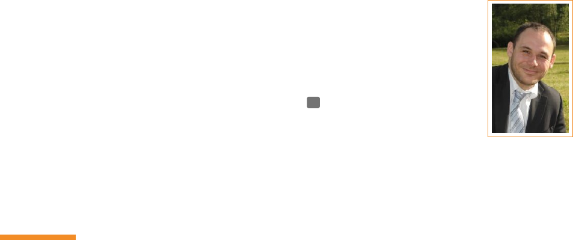

Raphaël Pinson

Technologiste Open-Source

2, rue Favre

73000 Chambéry

 +33 (0) 673 524 413

 +33 (0) 456 753 683

 rpinson@gmail.com

www.linkedin.com/in/raphink/fr

 www.github.com/raphink

Permis B

Vous avez reçu gratuitement, donnez gratuitement

M .

Compétences

Domaines d’expertise

Systèmes

Debian

et Ubuntu

Paquets Debian/Ubuntu, création et gestion de dépôts logiciels, fermes de compilation (Debian

buildd/sbuild/pbuilder), installations automatisées (Debian FAI)

Gestion de

conguration

Puppet

†

, MCollective

†

, Augeas

Développement

Langages C, Perl, Python, Shell/Bash, Ruby, GNU

Make, Ada, Lua

Web HTML/XHTML, CSS, JavaScript, Ajax,

Jquery, PHP, Web sémantique

Frameworks Django, Google AppEngine, Google

Wave, Netvibes

Bases de

données

MySQL, PostgreSQL, NoSQL (GQL),

SPARQL

Formats XML/XPath, SGML, YAML/JSON,

RDF/RSS/FOAF

Méthodes Développement orienté objet, MVC,

Tests unitaires, UML

Gestion de

sources

RCS/CVS, SVN, Bazaar, Git, Mercurial Outils Autotools, Cmake, Doxygen,

NaturalDocs, Trac, Gforge, Launchpad,

GitHub

Administration système et réseau

Web Apache, Lighttpd, Nginx, Varnish, Bind,

Squid, Dansguardian, VsFTPd

Monitoring BB4/Hobbit, Nagios, Munin, Cacti,

Simple Event Correlator (Sec)

Mail Postx, Exim, SSMTP Backup Amanda, BackupManager

Installation et

déploiement

FAI, Kickstart, Reprepro, Cfengine,

Puppet

†

, MCollective

†

, Augeas

Réseau DHCPd, VLANs, OpenVPN, Keepalived

Systèmes

d’exploitation

GNU/Linux (Debian

†

, Ubuntu

,

RedHat), MacOS X, Windows, *BSD

Bases de

données

MySQL, PostgreSQL, SQLite,

BerkeleyDB

Virtualisation Xen, VMWare, OpenVZ, LXC, NX Sécurité SSL, PGP/GnuPG, OpenSSH

Bureautique et outils

Bureautique OpenOﬃce/LibreOﬃce, Microso

Oﬃce, Gimp, Inkscape

Gestion de

projet

TaskJuggler, GanttProject

Productivité Cartes Mentales (Mind Maps), GTD Wikis MediaWiki, Trac, MoinMoin

Édition T

X, L

X, X

X, LuaT

X Dactylographie QWERTY & AZERTY

*. Développeur

†. Contributeur

[figure not shown]

Expérience professionnelle et bénévolat

Expérience en informatique

..

2012

.

.

Développeur & Formateur Infrastructure, Chambéry, Camptocamp.

Développement d’infrastructures

– Automatisation d’infrastructures avec Puppet ;

– Mise en place de solutions cloud redondantes ;

– Conférences devops ;

– Formations techniques (Puppet, Augeas) ;

– Consultance technique avant-vente.

..

2006

.

2012

Ingénieur Systèmes, ORNESS puis Alten, Sophia Antipolis.

Consultant chez France Télécom

– Administration de Cfengine, FAI et du dépôt de paquets logiciels ;

– Restructuration et industrialisation du système de déploiement logiciel Debian/Ubuntu ;

– Administration de la plateforme Gforge (environnement de développement collaboratif) ;

– Développement d’outils d’assurance qualité des systémes et congurations ;

– Intégration de la plateforme d’intégration continue (Hudson) avec le déploiement logiciel

Debian/Ubuntu ;

– Supervision du parc de machines ;

– Écriture de documentation technique.

..

2008

.

.

Développeur, Augeas, Internet.

Développement, bugx et documentation :

– Écriture de lentilles Augeas ;

– Écriture de code en C ;

– Amélioration des congurations autotools ;

– Intégration de NaturalDocs (générateur de documentation) ;

– Conférences internationales (Belgique (FOSDEM)).

..

2005

.

.

Développeur/Mainteneur, Ubuntu, Internet.

Développement, bugx et documentation :

– Création, maintenance et revue de paquets logiciels ;

– Écriture de documentation technique pour les développeurs ;

– Administration du système d’assurance qualité des nouveaux paquets logiciels ;

– Développement d’un système d’automatisation de l’assurance qualité sur les paquets logiciels ;

– Gestion de bugs ;

– Conférences internationales (Hongrie, Allemagne (LinuxTag)).

..

2005

.

.

Contributeur Open-Source, Divers projets, Internet.

Contribution à diﬀérents projets :

– Flammard Bible Bot : Bot Google Wave, projet personnel en Python/AppEngine ;

– Ichthux : Création et maintenance d’une distribution Linux spécialisée basée sur Ubuntu ;

– Byobu : contribution de scripts et patches en Python et Bash ;

– Auteur CPAN : maintenance de plusieurs modules Perl sur le CPAN ;

– Auteur CTAN : maintenance de plusieurs paquets L

X sur le CTAN.

Autres Expériences

..

2009

.

.

Traducteur et Éditeur, La Colombe Calvary, Nice.

– Traduction de livres de théologie anglais en français ;

– Édition de livres avec L

X, X

X et LuaT

X ;

– Publication de livres avec des services d’impression à la demande (CreateSpace et Lulu).

..

Juillet 2004

.

•

Stage ouvrier, SNECMA, Moissy-Cramayel.

Assemblage et équilibrage de turboréacteurs

..

1999 – 2000

Équipier Secouriste, Croix-Rouge Française, Région Parisienne.

Équipier secouriste en équipe

[figure not shown]

Éducation

..

2013

.

•

Formateur Puppet, PuppetLabs, Amsterdam.

Formateur Oﬃciel des cours PuppetLabs (Puppet : les fondamentaux, Puppet Avancé, Étendre Puppet

avec Ruby)

..

2009

.

•

ITIL® v3 Foundation, EXIN, Sophia Antipolis.

Organisation et eﬃcacité du système d’information

..

2005

.

•

Étudiant en création, reprise et gestion d’entreprise, Créafort, Poitiers.

Gestion, Management, Marketing, Droit

..

2005

.

•

Étudiant en pédagogie (‘Gestion Mentale’), IFGM, Bordeaux.

Pédagogie, Didactique, Psychologie cognitive

..

2003 – 2005

Étudiant en ingénierie mécanique,

École Nationale Supérieure de Mécanique et d’Aérotechnique (ENSMA), Poitiers.

Mécanique des solides & des uides, Mathématiques, Combustion & Propulsion, Matériaux,

Automatique, Traitement du signal, Informatique, Management

..

2004

.

•

Licence de mécanique, Université de Poitiers, Poitiers.

Mécanique des solides & des uides, Mathématiques, Combustion & Propulsion, Matériaux,

Automatique, Traitement du signal, Informatique, Management

..

2002 – 2003

DEUG de chimie, Université de Paris XI, Orsay.

Chimie, Physique, Mathématiques

..

2000 – 2002

Étudiant en médecine (PCEM1), Université de Paris XI, Orsay.

Biologie, Chimie, Biochimie, Physique, Anatomie, Histologie, Physiologie, Droit

..

2000

.

•

Baccalauréat S, Lycée Blaise Pascal, Orsay, ‘mention bien’.

Certications

..

2013

.

•

Puppet Certied Developer, PuppetLabs, PCD0000011.

Automatisation d’infrastructure avec Puppet

..

2013

.

•

Puppet Certied Professional, PuppetLabs, PCP0000116.

Automatisation d’infrastructure avec Puppet

..

2009

.

•

ITIL® v3 Foundation Examination, EXIN055512.

Organisation et eﬃcacité du système d’information

Langues

Anglais Courant Pratique réguliére, conférences données en anglais

Espagnol Scolaire Pratique occasionnelle

Allemand Scolaire Étudié 9 ans à l’école

Centres d’intérêt

Musique Clarinette, piano, orgue, saxophone

Sport Randonnée, voile, golf, escalade

Vie associative Président de l’association culturelle ‘la Colombe de Savoie’

Membre Ubuntu

Autres Voyages, lecture